# Supply Side II: Public Institutions and Governance Capacity

POLISCI 158 · AI & Politics · Session 11 · Wednesday, October 28, 2026

Simone Paci

## Stanford Democracy Day: Should AI rule the world?

Tuesday, November 3 · 2–3 p.m.

2nd floor, Old Union

RSVP with the QR code

[figure not shown]

Flyer: Stanford Votes · Stanford Democracy Day · SIG

## Roadmap

1. Part I: The state as AI user
   - Explain how buying AI shifts capacity, discretion and accountability
   - Read how an observatory measures adoption
2. Part II: When automation fails
   - Argue where human review belongs
3. Part III: The state as regulator
   - Explain why AI is hard to regulate
   - Match regulatory tools to harms

# Part I: The state as AI user

## Would you trust a government chatbot with your benefits claim?

Show of hands: yes / no / depends on what?

## Government GenAI is spreading fast

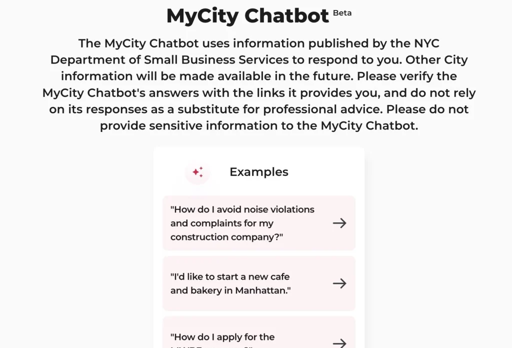

New York City: a service chatbot for businesses

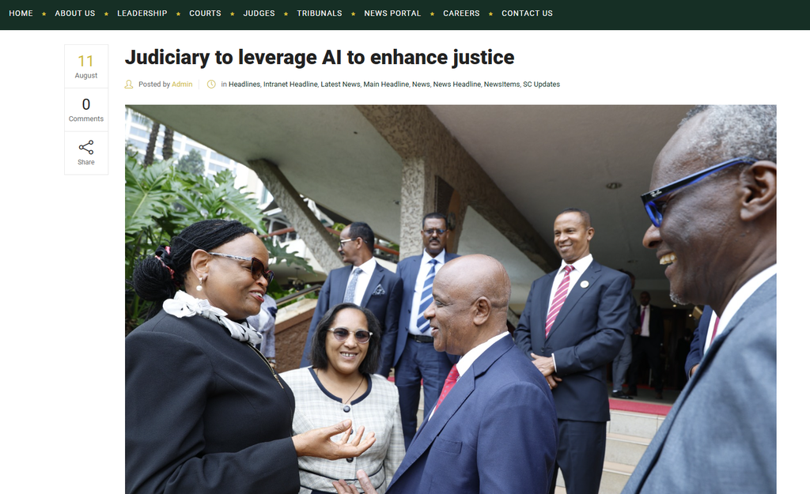

Kenya: the judiciary plans an AI policy

[figure not shown]

Albania: “Diella,” an AI “minister”

[The Markup on MyCity](https://themarkup.org/artificial-intelligence/2024/03/29/nycs-ai-chatbot-tells-businesses-to-break-the-law) · [judiciary.go.ke](https://judiciary.go.ke/judiciary-to-leverage-ai-to-enhance-justice/), Aug 2025 · [TIME on Diella](https://time.com/7324934/albania-ai-minister-diella/)

## Who gains power when an agency adopts AI?

**Agencies**

**Vendors**

**Frontline bureaucrats**

**The public**

- Capacity: who can do more?
- Discretion: who decides?
- Accountability: who answers?

## Who decides whether an agency buys GenAI?

California, June 29, 2026

- The state negotiates: Claude at a 50% discount per seat
- Agencies, cities and counties decide whether to buy

[figure not shown]

[gov.ca.gov, June 29, 2026](https://www.gov.ca.gov/2026/06/29/governor-newsom-announces-a-first-of-its-kind-partnership-providing-anthropic-tools-to-state-agencies-and-improving-services-for-californians/)

## What does the state refuse to buy?

**In force**

- DHS Exclusion and Removal Order #2026-01: DeepSeek out of federal civilian IT
- Signed July 24, 2026 · Federal Register, October 20, 2026 · under FASCSA
- Defense: FY2026 NDAA, Sec. 1532

**Proposed only**

- Broader bills, e.g., China FIREWALL Act (H.R. 10670)

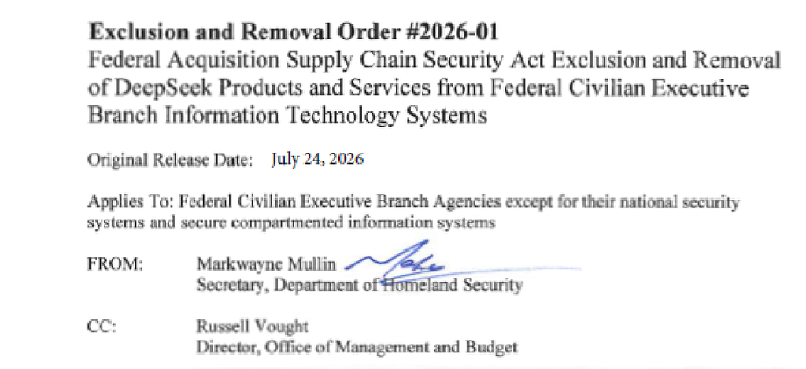

[Federal Register, FR Doc. 2026-21447](https://public-inspection.federalregister.gov/2026-21447.pdf)

## What are vendors selling to government?

January 28, 2025: ChatGPT Gov

- A version of ChatGPT agencies run in their own Microsoft Azure cloud

[figure not shown]

[openai.com, “Introducing ChatGPT Gov”](https://openai.com/global-affairs/introducing-chatgpt-gov/)

## Who writes the rules when the state buys AI?

**Buyer**

→

**Contract terms**

→

**Use**

- Stated: price, training
- Not stated: data use, duration, how many seats

## How would we know how much governments use AI?

No registry. No census. Press releases, tenders, news stories.

## Existing databases are skewed, lagged, and thin

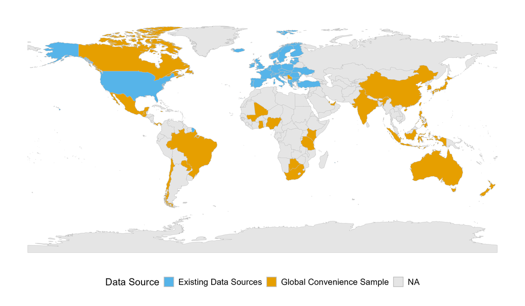

Highly skewed coverage

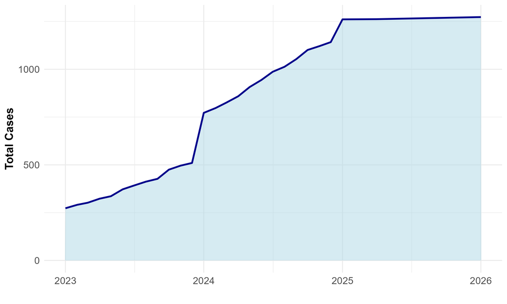

Fast growth, recorded with a lag

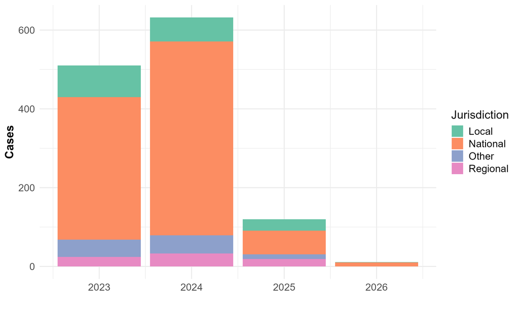

Institutional diversity in adoption

G3O talk deck (Sept 2026); figures from January 2026

## So, my colleagues and I are doing something about it

G3O · g3observatory.org

Funding: Institute for Humane Studies (seed) · Stanford research funds (RAs)

## Which public bodies count?

“One row in the registry is one public institution.”

National · First subnational · Second subnational · Local

Total institutions: **719,588**

[figure not shown]

g3observatory.org/research/methodology/registry, retrieved 2026-10-28

## What counts as government GenAI “activity”?

| Activity type | Example cases |
| --- | --- |
| Policy and guidance | Executive orders; acceptable-use rules; procurement standards; internal guidance |
| Pilots and experiments | Sandboxes and proofs of concept; time-bounded trials |
| Whole-of-government | Cross-agency governance bodies; training programs; platform rollouts |
| Internal operational use | Drafting, summarization, search assistants, translation, developer tooling |
| Public-facing services | Citizen- and business-facing chatbots; service navigation; complaint handling |

G3O talk deck (Sept 2026), activity typology

## How do we find evidence of use?

1. **Discovery:** search each institution, find its high-credibility sources
2. **Extraction:** a language model codes each source into fixed fields
3. **Cross-validation:** merge duplicates, prefer primary sources, resolve doubtful cases

“Each coded finding requires at least one verifiable source document.”

[figure not shown]

g3observatory.org/research/methodology/pipeline

## What counts as evidence of adoption?

**Evidence states**

- Documented activity
- Possible AI use
- No documented activity
- Not yet reviewed

“We distinguish between stated intent and verified deployment.”

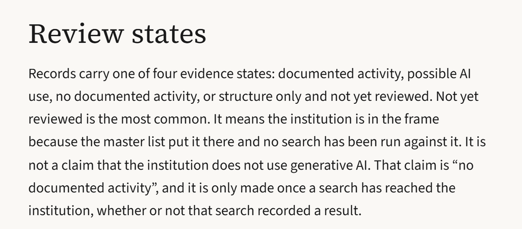

g3observatory.org/research/methodology

## Absence of evidence is not evidence of absence

**Every reviewed institution gets a verdict.**

**Earned negative**

Reviewed, nothing found

**Unclear**

Pipeline declined to judge

**Documented**

Activity found, evidence attached

**Publishing all three makes the denominator visible.**

G3O talk deck (Sept 2026)

## Live: g3observatory.org

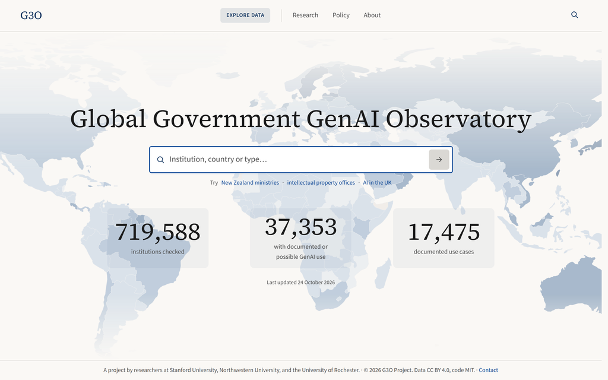

[g3observatory.org](https://g3observatory.org/)

## Your turn: what does G3O know about a place you know?

1. Go to **g3observatory.org**
2. Search your hometown, or any place you care about
3. Open one institution: what is its evidence state?

3 min · No device? Pair with a neighbor

Sharing is voluntary

## Where is use documented?

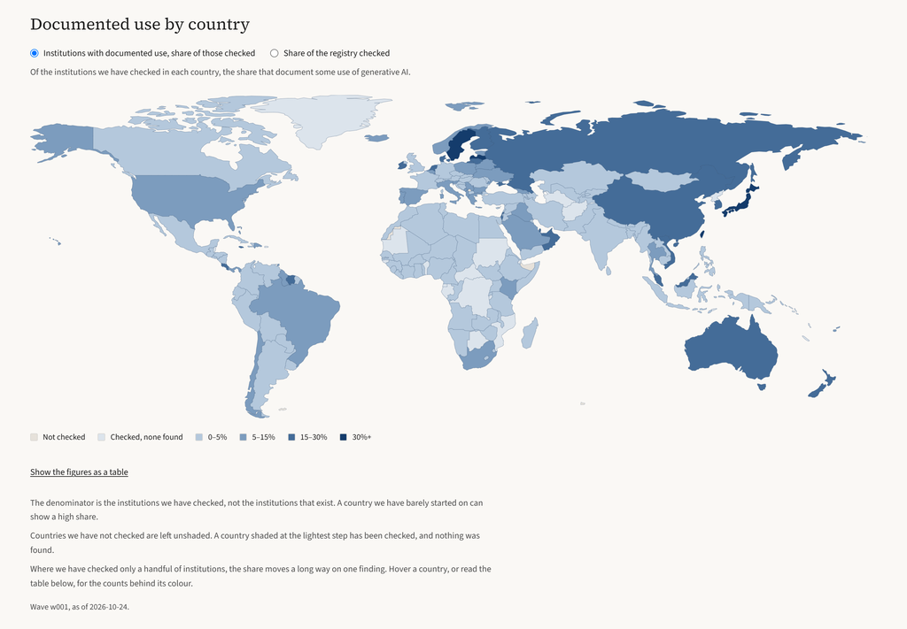

Documentation is concentrated where the search has looked and where institutions publish.

g3observatory.org/research/visualizations, retrieved 2026-10-28 · “Wave w001, as of 2026-10-24.”

## What is the documented activity for?

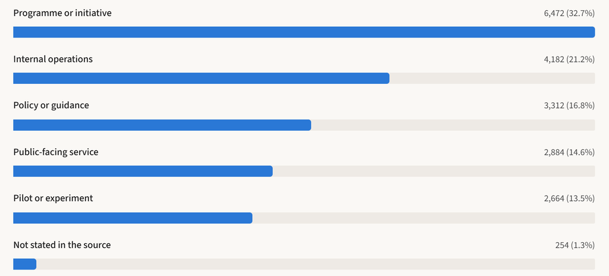

g3observatory.org/research/visualizations, Activity types, retrieved 2026-10-28 · “Wave w001, as of 2026-10-28.”

## When did documented use first appear?

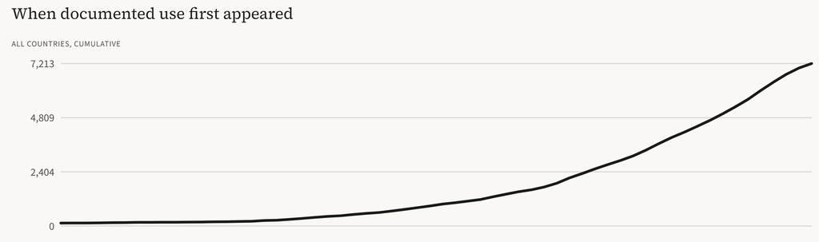

A count of institutions first documented by each month: it cannot fall.

g3observatory.org/research/visualizations, Over time, retrieved 2026-10-28 · “Wave w001, as of 2026-10-28.”

## What can an observatory not see?

- Use that is never published
- Places with less web coverage
- Announcements that never ship

# Part II: When automation fails

## Though it may not always live up to expectations

[figure not shown]

[figure not shown]

“NYC’s AI Chatbot Tells Businesses to Break the Law”

[The Markup, March 29, 2024](https://themarkup.org/artificial-intelligence/2024/03/29/nycs-ai-chatbot-tells-businesses-to-break-the-law) · screenshots from the G3O talk deck

## What happens when an algorithm decides who committed fraud?

Michigan, 2013–2015: MiDAS

- Flags claimants for fraud
- Issues the determination and the penalty
- Collects from wages and tax refunds

[figure not shown]

[Charette, IEEE Spectrum, 2018](https://spectrum.ieee.org/michigans-midas-unemployment-system-algorithm-alchemy-that-created-lead-not-gold)

## How often did the computer get it wrong?

40,195

fraud cases decided by computer alone

85%

of those findings reversed on review

[figure not shown]

[Michigan Talent Investment Agency–UI review, August 11, 2017](https://www.michigan.gov/leo/news/2017/08/11/michigans-unemployment-agency-completes-review-of-fraud-determination-cases-comprehensive-changes-u)

## Who answered for it?

*Bauserman v. Unemployment Insurance Agency*

$20 million settlement · final approval January 29, 2024

[figure not shown]

[Michigan Attorney General, January 30, 2024](https://www.michigan.gov/ag/news/press-releases/2024/01/30/class-action-settlement-approved-by-court-of-claims)

## Where should a human stay in the loop?

**Flag**

→

**Decide**

→

**Penalize**

→

**Collect**

Your role: Claimant · Caseworker · Agency head · Vendor

1. Alone · 1 min: pick one step for human review
2. Pairs · 6 min: give one reason from your role
3. Share · 5 min: one step, one reason, by role

Solo or written answers welcome

# Part III: The state as regulator

## Why regulate one model with many uses?

**One model**

chatbot

hiring screen

translation

fraud flag

## When should we regulate?

“When change is easy, the need for it cannot be foreseen; when the need for change is apparent, change has become expensive, difficult and time consuming.”

David Collingridge, *The Social Control of Technology* (1980)

[figure not shown]

archive.org/details/socialcontroloft0000coll

## Who knows more, firms or governments?

**Firms**

data · models · engineers

**Governments**

press releases · procurement documents

## What tools does a regulator have?

**Guidance**

NIST AI RMF (2023)

**Audits**

NYC bias audits for hiring tools

**Liability**

EU Product Liability Directive (2024)

**Licensing**

China’s filing gate (2023): nearest real case

**Disclosure**

EU AI Act Art. 50

## Which tool fits which harm?

Tools: Guidance · Audits · Liability · Licensing · Disclosure

**A.** A city’s benefits chatbot tells eligible residents they do not qualify

**B.** An agency buys a risk-scoring model it cannot inspect

**C.** A hiring tool screens out more applicants from one group

**D.** A new public chatbot could shape opinion at scale, with no review before launch

**E.** A synthetic video of a candidate spreads before an election

**F.** Staff do not know when they may use AI to draft decisions

## Which approach would you bet on for AI?

**1**

Guidance

**2**

Audits

**3**

Liability

**4**

Licensing

**5**

Disclosure

With your neighbor:

1. Pick a number from 1 to 5
2. Pairs · 2 min: one pro and one con of that approach for AI
3. Share · 1 min: one pair per number

Solo or written answers welcome

## When do the EU’s rules bite?

- Feb 2, 2025: prohibitions
- Aug 2, 2025: general-purpose AI models
- Aug 2, 2026: general application; transparency (Art. 50)
- Dec 2, 2027: high-risk uses (Annex III), deferred
- Aug 2, 2028: high-risk products (Annex I), deferred
- **Aug 2, 2030: existing high-risk systems used by public authorities**

Amended by the Digital Omnibus on AI, Reg. (EU) 2026/1744 · 2030 deadline: AI Act, Reg. (EU) 2024/1689, Art. 111(2)

[figure not shown]

[EC AI Act Service Desk, timeline](https://ai-act-service-desk.ec.europa.eu/en/ai-act/timeline/timeline-implementation-eu-ai-act); [EUR-Lex](https://eur-lex.europa.eu/eli/reg/2026/1744/oj/eng)

## What should you take from today?

1. Buying AI is governing: the contract sets the rules
2. Automation scales errors; review belongs before the penalty
3. No single tool fits every harm

## See you next class

Implementation Milestone · Sun, Nov 15, 11:59 p.m.

Monday, November 2

Data Centers · Simone Paci